# DS202W - DS202W - Summer Summative (‘Exam’)

Author

23007

```r
suppressWarnings({
library(tidyverse)
library(tidymodels)
library(dplyr)
library(viridis)
library(tidytext)
library(tidygraph)
library(textdata)
library(textTinyR)
library(tidyr)
library(vip)
})
```

```
• Learn how to get started at https://www.tidymodels.org/start/
```

```r
suppressWarnings({
library(quanteda)
library(quanteda.textstats)
library(quanteda.textplots)
library(quanteda.textmodels)
library(ggplot2)
library(igraph)
library(widyr)
library(ggraph)
library(stringr)
library(stringdist)
library(ranger)
})
```

```
Package version: 4.0.2
Unicode version: 15.1
ICU version: 74.1
```

```
Parallel computing: 12 of 12 threads used.
```

```
See https://quanteda.io for tutorials and examples.
```

# Part 1

## Q1 - Answer

What do you see? Why the modelling choices were made?

The data scientist used a decision tree classifier to predict the 3 classes: healthy (0), pre-diabetic (1) and diabetic (2). My observations fall into 3 categories: the data, model and visualisation.

With regards to the data I can clearly observe:

Character variables, e.g Diabetes_012, were converted to factors for the model to understand them as categories. Also the data was split into train (70%) and test (30%) sets (using initial_split() ) so that the model could be evaluated on unseen data. No other data pre-processing steps were used. This may have been because the data is numeric and most predictors are binary which is suitable for decision trees to split and also means that no scaling was needed like normalisation or standardisation. Also the model is robust to both outliers and missing values so there would be no need to impute the data.

With regards to the model I can clearly observe:

In the code, the decision tree argument, cost_complexity = 0. This is an argument for decision trees which controls how easily new sub trees can be grown. Its purpose is to trim sub trees with high error/cost to reduce the models likelihood of overfitting. Since its set to zero, the decision tree will keep splitting unchecked or until it reaches a stopping criterion, leaving us with a complex model. By that point it will have memorised the training data, outliers and have simply captured noise. As a result it will perform worse on evaluation due to overfitting than if it it were to be pruned.

It could also be that he was trying to capture or find complex relations in the data. Or maybe he just wanted to train the model fast because pruning can increase training time. What seems more likely is that the data scientist choose to not prune the tree because he wasn’t concerned about interpretability and more interested in predictive power of his model. Despite this I still think some pruning would have been beneficial to overall predictive power as it would reduce overfitting to the training data.

From the code its also evident the data scientist has used the tidy model workflow to build his decision tree classifier. He starts with a recipe which ordinarily contains the pre-processing steps that will be applied to the predictors of our choosing in the data set of our choosing for the models of our choosing. He then specifies the model as decision tree and sets a workflow which streamlines the fitting and evaluating steps. He may have chosen the decision tree because it in a way ranks which features have the most predictive power by using them earlier in the tree as a splitting condition. This can be used to tell us which features are important relative to others when predicting diabetes.

With regards to the visualisation I can clearly observe:

He used the rpart.plot to get the visual of the decision tree. Typically these plots are highly interpretable due to them being neat flowcharts. But it appears very cluttered here due to there being no pruning, so the tree kept splitting unchecked. Despite it being cluttered its structure can be identified.

There are tree nodes, split in the branches and leaves. The tree nodes are like if-else statements which use some feature from the data (e.g HighBP < 0.5) to linearly separate the data. By splitting the data many times the model can overcome even non-linear data. The branches start from a node and reach a new leaf. The final leaves at the end are called terminal leaves and they represent the final classification (Diabetes_012) of some corresponding row in the data.

Overall decision trees were a pretty solid choice for this classification task. They’re not very finicky with data so not really any data pre-processing was needed in the recipe. Through hierarchical splitting they can handle non-linear data and with pruning can spit out an interpretable flowchart. That being said this particular model didn’t make use of cross validation, hyperparameter tuning and didn’t even use any evaluation metrics suitable for classification predictions. Moreover, he didn’t check for class imbalances which could skew the models results. After a quick check I get the following instances in R: 213703 (for 0), 4631 (for 1) and 35346 (for 2). Such a situation could be remedied with upsampling, downsampling or class wieghts. Ultimately the model was quite simple and didn’t make use of the mentioned techniques so it could maybe be treated as a baseline model but not a final model.

## Q2 - Data Processing

Keeping all else the same the things I would do differently includes the following: feature engineering, deal with class imbalances and use random forests with CV/hyperparameter tuning. I would evaluate the models using ROC-AUC, accuracy, confusion matrix, precision, recall, sensitivity.

Data pro-processing and feature engineering:

Some variables are more suitable as categories like age groups or income brackets. And I would create interaction terms to try to combine the effect of certain variables e.g physical activity and BMI. This would be a more efficient use of the predictors I have available to me. I would also check for class imbalances and either downsample or upsample to balance the classes. I could also just use stratified cross validation to address class imbalances. This is so the final predictions are not skewed to any particular class.

Model Construction:

I would use an ensemble model like a random forest which averages the outcome of many decision trees. It typically gives higher accuracy and better predictive power at the cost of a slight decrease in interpretability. I would optimise the model by using cross validation and hyperparameter tuning to find its optimal parameters for number of trees and mtry. I would then fit and evaluate a final tuned random forest model.

Cross validation would allow me to average my results across many folds of data so that my results are as accurate as can be to the estimates of the whole data set’s accuracy or desired metric. To find the most optimal parameters I would select a metric I was interested in, e.g accuracy and plot a graph with accuracy on the y axis and a parameter (e.g number of trees) on the x axis. Then simply choose the number of trees which maximises desired parameter.

Model Evaluation:

To evaluate the model I would first plot a ROC-AUC curve. The ROC curve needs to be more skewed to the left as it results in a higher true positive rate for a little false positive rate. This is important when we particularly care about predicting the positive class correctly. E.g in the case where a positive case represents an infected person because we need to find them to contain the infection. If the ROC was closer to a y=x line then its no better than a 50/50 chance or a 50% classifier. The area under curve is better when its higher because it just means that we get more true false positive rate for a given unit of false positive rate compared to another roc-auc curve.

I would also use a Confusion matrix which neatly displays the true positive rate, false positive rate, true negative rate and false negative rate. These could be used to find the precision, recall and f-measure. Precision gives us the proportion of true positive predictions out of all positive predictions. If we care about true positives, which we normally do, then the higher the better. Recall tells us the proportion of true positive predictions among all actual positive instances in the dataset. F-measure is the harmonic mean of the two and for all 3 cases the higher the better.

Precision: TP / (TP + FP)

Recall: TP / (TP + FN)

F-measure: 2 * (Precision * Recall) / (Precision + Recall)

Feature Importance:

In order to determine which features have the most predictive power I could use the function: vip::vip(final_rf_model). It gives me the variable importance plots which are calculated using a decrease or increase in some metric like gini impurity, accuracy, etc…. Knowing this I can use fewer variables in another model if I am trying to compare the performance of multiple models (which I would ideally do)

```r
# Read data
diabetes_data <- read.csv("C:/Users/David Moraes/Downloads/cdc_diabetes.csv")
```

```r
# Feature Engineering: BMI Categories
diabetes_data <- diabetes_data %>%
  mutate(BMI_Category = case_when(
    BMI < 18.5 ~ "Underweight",
    BMI >= 18.5 & BMI < 25 ~ "Normal Weight",
    BMI >= 25 & BMI < 30 ~ "Overweight",
    BMI >= 30 ~ "Obese"
  ))

# Feature Engineering: Age Groups
diabetes_data <- diabetes_data %>%
  mutate(Age_Group = case_when(
    Age < 35 ~ "Young Adults",
    Age >= 35 & Age < 65 ~ "Middle-aged Adults",
    Age >= 65 ~ "Seniors"
  ))

# Feature Engineering: Interaction Terms (e.g., BMI and Physical Activity)
diabetes_data <- diabetes_data %>%
  mutate(BMI_PhysicalActivity = BMI * PhysActivity)

# Display the modified diabetes_data table
head(diabetes_data)
```

```
  Diabetes_012 HighBP HighChol CholCheck BMI Smoker Stroke HeartDiseaseorAttack
1            0      1        1         1  40      1      0                    0
2            0      0        0         0  25      1      0                    0
3            0      1        1         1  28      0      0                    0
4            0      1        0         1  27      0      0                    0
5            0      1        1         1  24      0      0                    0
6            0      1        1         1  25      1      0                    0
  PhysActivity Fruits Veggies HvyAlcoholConsump AnyHealthcare NoDocbcCost
1            0      0       1                 0             1           0
2            1      0       0                 0             0           1
3            0      1       0                 0             1           1
4            1      1       1                 0             1           0
5            1      1       1                 0             1           0
6            1      1       1                 0             1           0
  GenHlth MentHlth PhysHlth DiffWalk Sex Age Education Income  BMI_Category
1       5       18       15        1   0   9         4      3         Obese
2       3        0        0        0   0   7         6      1    Overweight
3       5       30       30        1   0   9         4      8    Overweight
4       2        0        0        0   0  11         3      6    Overweight
5       2        3        0        0   0  11         5      4 Normal Weight
6       2        0        2        0   1  10         6      8    Overweight
     Age_Group BMI_PhysicalActivity
1 Young Adults                    0
2 Young Adults                   25
3 Young Adults                    0
4 Young Adults                   27
5 Young Adults                   24
6 Young Adults                   25
```

```r
# Check class imbalance
class_distribution <- table(diabetes_data$Diabetes_012)
print(class_distribution)
```

```
     0      1      2
213703   4631  35346
```

```r
set.seed(123)

# Separate data by class
class0_data <- diabetes_data[diabetes_data$Diabetes_012 == 0, ]
class1_data <- diabetes_data[diabetes_data$Diabetes_012 == 1, ]
class2_data <- diabetes_data[diabetes_data$Diabetes_012 == 2, ]

# Calculate the maximum class size
max_class_size <- max(nrow(class0_data), nrow(class1_data), nrow(class2_data))

# Oversample and undersample
class0_oversampled <- class0_data[sample(nrow(class0_data), size = max_class_size, replace = TRUE), ]
class1_oversampled <- class1_data[sample(nrow(class1_data), size = max_class_size, replace = TRUE), ]
class2_oversampled <- class2_data[sample(nrow(class2_data), size = max_class_size, replace = TRUE), ]

class0_undersampled <- class0_data[sample(nrow(class0_data), size = max_class_size, replace = FALSE), ]

# Combine oversampled and undersampled data
balanced_data <- rbind(class0_oversampled, class1_oversampled, class2_oversampled, class0_undersampled)

# Shuffle the data
balanced_diabetes_data <- balanced_data[sample(nrow(balanced_data)), ]
```

```r
# Convert necessary columns to factors
balanced_diabetes_data$BMI_Category <- as.factor(balanced_data$BMI_Category)

balanced_diabetes_data$Age_Group <- as.factor(balanced_diabetes_data$Age_Group)

balanced_diabetes_data$Diabetes_012 <- as.factor(balanced_diabetes_data$Diabetes_012)

# Verify data types
str(balanced_diabetes_data)
```

```
'data.frame':   854812 obs. of  25 variables:
 $ Diabetes_012        : Factor w/ 3 levels "0","1","2": 1 1 1 2 1 1 1 1 1 3 ...
 $ HighBP              : num  0 0 0 1 0 0 1 0 1 1 ...
 $ HighChol            : num  0 1 0 1 0 0 0 0 0 1 ...
 $ CholCheck           : num  1 1 1 1 1 1 1 1 1 1 ...
 $ BMI                 : num  31 20 29 36 25 29 29 38 21 47 ...
 $ Smoker              : num  0 0 0 0 0 1 0 0 1 0 ...
 $ Stroke              : num  0 0 0 0 0 0 1 0 0 0 ...
 $ HeartDiseaseorAttack: num  0 0 0 0 0 0 0 0 0 0 ...
 $ PhysActivity        : num  1 1 1 0 1 1 1 0 0 1 ...
 $ Fruits              : num  1 0 1 1 1 1 1 0 0 0 ...
 $ Veggies             : num  1 1 1 1 1 1 1 1 1 1 ...
 $ HvyAlcoholConsump   : num  0 0 0 0 0 0 0 0 0 0 ...
 $ AnyHealthcare       : num  1 1 1 1 1 1 1 1 0 1 ...
 $ NoDocbcCost         : num  0 0 0 0 0 0 0 0 1 0 ...
 $ GenHlth             : num  2 1 3 3 2 4 2 4 1 3 ...
 $ MentHlth            : num  0 5 3 0 2 0 0 0 0 0 ...
 $ PhysHlth            : num  0 0 0 0 12 0 0 30 0 0 ...
 $ DiffWalk            : num  0 0 0 1 0 1 0 1 0 0 ...
 $ Sex                 : num  0 0 1 0 1 1 0 0 0 1 ...
 $ Age                 : num  6 10 5 13 5 9 13 5 6 11 ...
 $ Education           : num  5 6 6 5 6 5 4 6 5 4 ...
 $ Income              : num  4 7 8 2 7 4 6 8 7 6 ...
 $ BMI_Category        : Factor w/ 4 levels "Normal Weight",..: 1 3 3 3 1 1 1 3 3 1 ...
 $ Age_Group           : Factor w/ 1 level "Young Adults": 1 1 1 1 1 1 1 1 1 1 ...
 $ BMI_PhysicalActivity: num  31 20 29 0 25 29 29 0 0 47 ...
```

```r
# Check class imbalance
class_distribution <- table(balanced_diabetes_data$Diabetes_012)
print(class_distribution)
```

```
     0      1      2
427406 213703 213703
```

```r
# Set seed for reproducibility
set.seed(123)

# Determine the size of the training set (e.g., 80%)
train_size <- 0.8

# Determine the number of rows for the training set
num_train <- round(nrow(balanced_diabetes_data) * train_size)

# Split the data into training and testing sets
train_data <- balanced_diabetes_data[1:num_train, ]
test_data <- balanced_diabetes_data[(num_train + 1):nrow(balanced_diabetes_data), ]
```

```r
#Will use these folds for cross validation for models
set.seed(23007)

folds <- vfold_cv(train_data, v = 2)

folds
```

```
#  2-fold cross-validation
# A tibble: 2 × 2
  splits                  id
  <list>                  <chr>
1 <split [341925/341925]> Fold1
2 <split [341925/341925]> Fold2
```

## Q2 - Random Forrest and Hyper-parameter tuning

After finding my ideal parameter values I would have fitted my final model and workflow and evaluated its performance of the test set. Then I would have checked my confusion matrix and values for precision, recall and f measure (hoping to maximse them all). If I was comparing random forests to boosted trees I would have compared their Roc-Auc curves.

```r
#Now using Random Forests
set.seed(23007)

rf_recipe <-
    recipe(Diabetes_012 ~ BMI_PhysicalActivity + BMI_Category, data = train_data)
```

```r
set.seed(23007)

rf_specification <-
  rand_forest(trees = 1000) %>%
  set_engine("ranger", importance = "impurity") %>%
  set_mode("classification")

rf_wf <-
    workflow() %>%
    add_recipe(rf_recipe) %>%
    add_model(rf_specification)
```

```r
set.seed(23007)

rf_tune_spec <- rand_forest(trees = tune()) %>%
  set_engine("ranger", importance = "impurity") %>%
  set_mode("classification")

rf_tune_wf <-  workflow() %>%
  add_recipe(rf_recipe) %>%
  add_model(rf_tune_spec)
```

```r
set.seed(23007)

tree_grid_trial <- grid_regular(trees(range = c(100, 500)), levels = 5)
```

```r
# set.seed(23007)
#
# rf_tune_results <- rf_tune_wf %>%
#   tune_grid( resamples = folds,  grid = tree_grid_trial )
#
# View(rf_tune_results)
```

```r
# set.seed(23007)
# rf_tune_results %>%
#   collect_metrics()
```

```r
# set.seed(23007)
#
# best_rf <- rf_tune_results %>%
#   select_best(metric = "accuracy")
#
# best_rf
```

```r
# set.seed(23007)
#
# rf_tune_results %>%
#   collect_metrics() %>%
#   mutate(trees = factor(trees)) %>%
#
#   ggplot(aes(min_n, mean, color = trees)) +   geom_line(size = 1.5, alpha = 0.6) +   geom_point(size = 2) +   facet_wrap(~ .metric, scales = "free", nrow = 2) +   scale_x_log10(labels = scales::label_number()) +   scale_color_viridis_d(option = "plasma", begin = .9, end = 0)
```

## Q2 - Final Workflow and Fit

```r
# #From here its about finalising the workflow and fit
# set.seed(23007)
#
# final_rf_wf <-    rf_tune_wf %>%
#   finalize_workflow(best_rf)
#
# final_rf_wf
```

```r
# set.seed(23007)
#
# final_rf_fit <-  final_rf_wf %>%
#   last_fit(dataset_split)
#
# final_rf_fit %>%  collect_metrics()
```

```r
# set.seed(23007)
#
# final_rf_model <- final_rf_fit %>%
#   extract_fit_parsnip()
```

```r
# set.seed(23007)
#
# final_rf_model %>%
#   augment(new_data =  test_data) %>%
#   conf_mat(truth=ranking_type, estimate=.pred_class)
```

```r
# set.seed(23007)
#
# final_rf_model %>%
#   augment(new_data =  test_data) %>%
#   conf_mat(truth=ranking_type, estimate=.pred_class) %>%
#   summary()
```

```r
# # Visualize variable importance
# vip::vip(final_rf_model)
```

## Q3 - Poisoned Data

Here the goal is to find a way to predict labels despite not knowing how many of them have been poisoned. This is not a good situation and I don’t think much meaningful analysis can be done here with supervised methods. My hope is that unsupervised learning could find a way to group the majority of the data so that other new observations would mostly fall into clusters that could be used to predict their class/label (whether healthy, pre-diabetic or diabetic).

```r
# Load necessary libraries
library(tidymodels)
library(tidyverse)
library(fpc)  # For DBSCAN
library(ggplot2)
```

```r
set.seed(123)

# Function to poison a percentage of labels in the target column
poison_labels <- function(data, target_column, poison_percentage) {
  set.seed(42)
  n <- nrow(data)
  num_to_poison <- round(n * poison_percentage / 100)

  # Ensure the target column is a factor
  data[[target_column]] <- as.factor(data[[target_column]])

  # Randomly select indices to poison
  poison_indices <- sample(seq_len(n), size = num_to_poison, replace = FALSE)

  # Possible class labels
  possible_labels <- levels(data[[target_column]])

  # Poison the selected labels
  for (i in poison_indices) {
    current_label <- data[[target_column]][i]
    new_label <- sample(possible_labels[possible_labels != current_label], 1)
    data[[target_column]][i] <- new_label
  }

  return(data)
}

# Poison 10% of the Diabetes_012 labels in the dataset
# Change the last parameter to change the proportion of labels poisoned
poisoned_data <- poison_labels(diabetes_data, "Diabetes_012", 10)

# Inspect the first few rows of the poisoned data
head(poisoned_data)
```

```
  Diabetes_012 HighBP HighChol CholCheck BMI Smoker Stroke HeartDiseaseorAttack
1            1      1        1         1  40      1      0                    0
2            0      0        0         0  25      1      0                    0
3            0      1        1         1  28      0      0                    0
4            0      1        0         1  27      0      0                    0
5            0      1        1         1  24      0      0                    0
6            1      1        1         1  25      1      0                    0
  PhysActivity Fruits Veggies HvyAlcoholConsump AnyHealthcare NoDocbcCost
1            0      0       1                 0             1           0
2            1      0       0                 0             0           1
3            0      1       0                 0             1           1
4            1      1       1                 0             1           0
5            1      1       1                 0             1           0
6            1      1       1                 0             1           0
  GenHlth MentHlth PhysHlth DiffWalk Sex Age Education Income  BMI_Category
1       5       18       15        1   0   9         4      3         Obese
2       3        0        0        0   0   7         6      1    Overweight
3       5       30       30        1   0   9         4      8    Overweight
4       2        0        0        0   0  11         3      6    Overweight
5       2        3        0        0   0  11         5      4 Normal Weight
6       2        0        2        0   1  10         6      8    Overweight
     Age_Group BMI_PhysicalActivity
1 Young Adults                    0
2 Young Adults                   25
3 Young Adults                    0
4 Young Adults                   27
5 Young Adults                   24
6 Young Adults                   25
```

## Q3 - PCA

Rather than using all the predictors, I’ll first find the principal components that contribute most to the variance in the data. These will serve as my x and y axis that give me the most predictive power.

```r
set.seed(123)

pca_recipe <-
 # unsupervised so no need for an outcome variable
  recipe(~., data = balanced_diabetes_data) %>%
  #make sure to ignore non-numeric columns (education, marital_status) and irrelevant predictors (id, year_birth) from the list of predictors

  #apply knn imputation to fill missing values
  step_impute_knn(all_numeric_predictors(), neighbors = 3) %>%
  # remove zero variance predictors as they don't carry any information
  step_zv(all_numeric_predictors()) %>%
  # normalize the data to avoid out-sized impact of some variables
  step_normalize(all_numeric_predictors()) %>%
  # apply principal component analysis
  step_pca(all_numeric_predictors(), num_comp = 2, keep_original_cols=TRUE) %>%
  prep()
```

```r
set.seed(123)

#applying recipe to our features to select PC1 and PC2

pca_results <- bake(pca_recipe, balanced_diabetes_data)
pca_results %>%
  select(PC1, PC2) %>%
  head()
```

```
# A tibble: 6 × 2
      PC1     PC2
    <dbl>   <dbl>
1 -1.78    0.579
2 -1.96    0.0472
3 -2.29    0.320
4  2.11   -0.488
5 -2.13    0.555
6  0.0901 -0.443
```

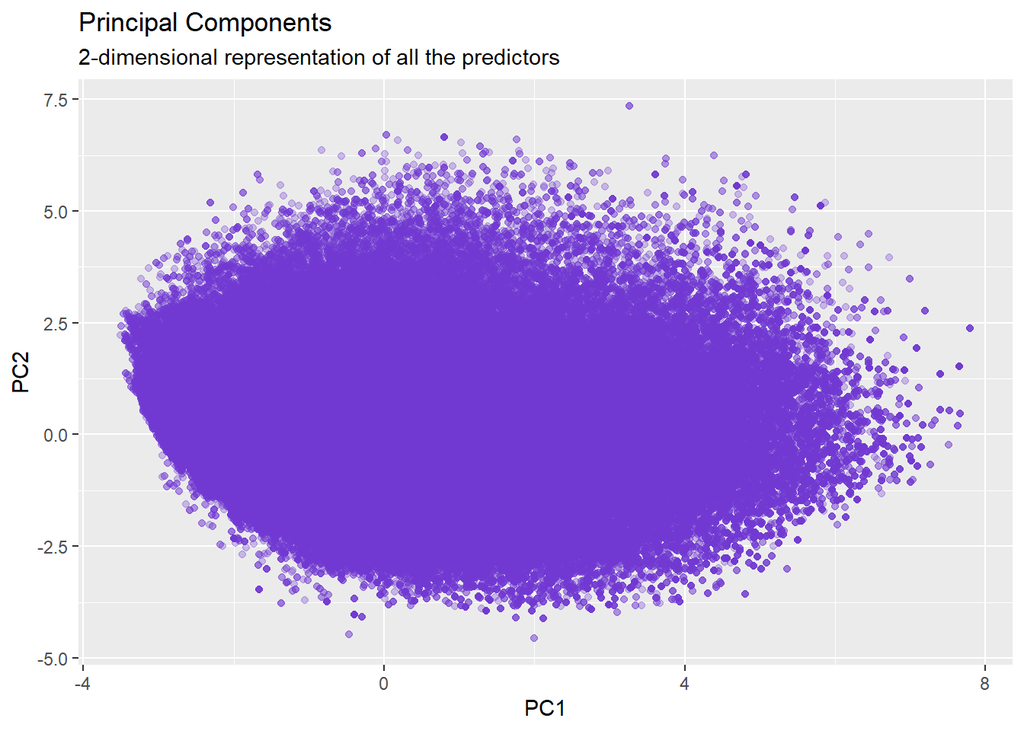

```r
set.seed(123)

ggplot(pca_results, aes(PC1, PC2)) +
  geom_point(alpha=0.3,color="#7038d1") +
  ggtitle("Principal Components", subtitle = "2-dimensional representation of all the predictors")
```

```r
set.seed(123)

pca_fit <- pca_recipe$steps[[4]]$res
```

```r
set.seed(123)

eigenvalues <-
  pca_fit %>%
  tidy(matrix = "eigenvalues")
```

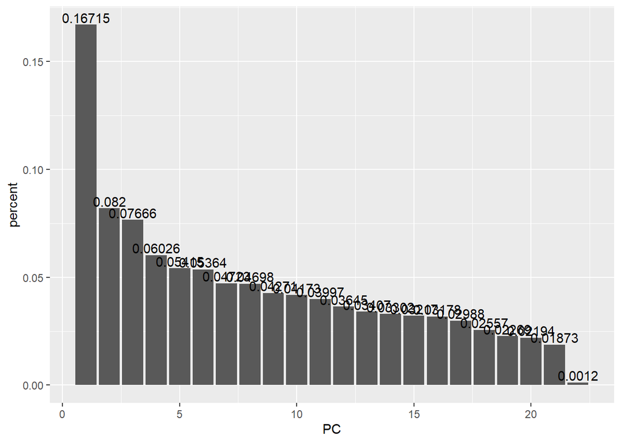

```r
set.seed(123)

#Plotting eigenvalues (principal components) to see each ones influence over the total variance.
eigenvalues %>%
  filter(PC <= 23) %>%
  ggplot(aes(PC, percent)) +
  geom_col()+
  geom_text(aes(label = percent), vjust = -0.2)
```

## Q3 - Cluster Analysis with K-means cluster

My approach here is to use cluster analysis to see if the unsupervised machine learning model won’t be deterred by the poisoned labels. I will check the clusters found by k-means for which labels are placed in each cluster. I think the largest proportion of labels that belong to that cluster would be the indication that the model is able to classify most data points. The ones that seem anomalous could be treated as the poisoned labels.

```r
set.seed(123)

recipe_kmeans <- recipe(~ ., data = balanced_diabetes_data) %>%
    step_impute_knn(all_numeric_predictors, neighbors = 3) %>%
    step_normalize(all_numeric_predictors())
```

```r
set.seed(123)

kclust =
  pca_results  %>%
  select(PC1, PC2) %>%
  kmeans(centers = 3)

tidy(kclust)
```

```
# A tibble: 3 × 5
     PC1    PC2   size withinss cluster
   <dbl>  <dbl>  <int>    <dbl> <fct>
1  2.61   0.425 217860  748508. 1
2 -1.49   0.787 329430  617568. 2
3 -0.259 -1.14  307522  437111. 3
```

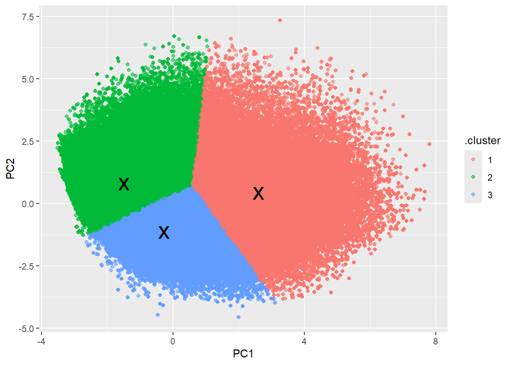

```r
set.seed(123)

augment(kclust, pca_results) %>%
  ggplot() +
  geom_point(aes(x=PC1, y=PC2, color=.cluster), alpha=0.6) +
  geom_point(data = tidy(kclust), aes(x=PC1, y=PC2), size = 8, shape = "x")
```

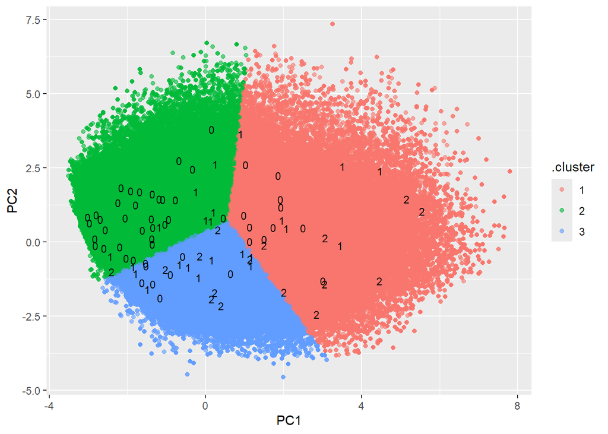

```r
set.seed(123)

# Create a plot with points colored by cluster
plot <- augment(kclust, pca_results) %>%
  ggplot() +
  geom_point(aes(x = PC1, y = PC2, color = .cluster), alpha = 0.6)

# Randomly select 10 points
subset_data <- augment(kclust, pca_results) %>%
  sample_n(size = 90)  # Randomly select 10 points

# Add text annotations for Diabetes_012
plot +
  geom_text(data = subset_data, aes(x = PC1, y = PC2, label = Diabetes_012), size = 3, color = "black")
```

```r
set.seed(123)

#  `kclust` is the result of k-means clustering
# Add cluster assignments to the original dataset
balanced_diabetes_data$cluster <- kclust$cluster

# Group the data by cluster and label, then calculate counts
cluster_counts <- balanced_diabetes_data %>%
  group_by(cluster, Diabetes_012) %>%
  summarise(count = n()) %>%
  ungroup()
# Print the counts for each cluster and label
print(cluster_counts)
```

```
# A tibble: 9 × 3
  cluster Diabetes_012  count
    <int> <fct>         <int>
1       1 0             61986
2       1 1             68629
3       1 2             87245
4       2 0            247885
5       2 1             52530
6       2 2             29015
7       3 0            117535
8       3 1             92544
9       3 2             97443
```

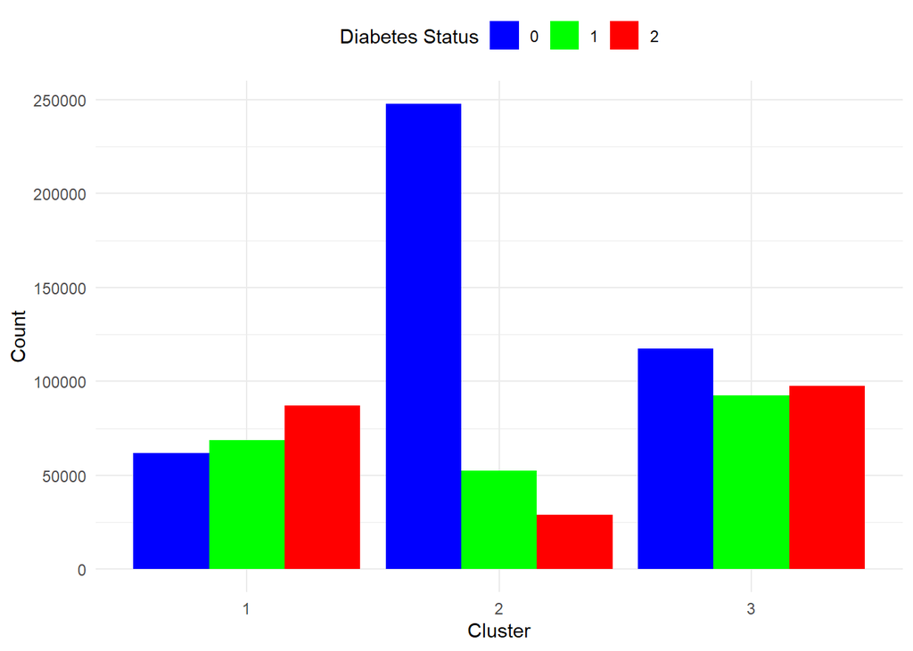

```r
set.seed(123)

# Plot the counts of each label within each cluster
ggplot(cluster_counts, aes(x = factor(cluster), y = count, fill = factor(Diabetes_012))) +
  geom_bar(stat = "identity", position = "dodge") +
  labs(x = "Cluster", y = "Count", fill = "Diabetes Status") +
  scale_fill_manual(values = c("blue", "green", "red")) +  # Adjust colors as needed
  theme_minimal() +
  theme(legend.position = "top")
```

# Part 2

Here I use K means to determine if there are any relationships between variables used to inform doctors about how patients will be affected in their drug trials/treatments.

While K means is good at separating linear data and is not affected by density it would struggle with classes of data that overlap or surround one another. Also they assign all data points to a cluster so they are unable to leave out outliers. It may have been better to use DB scan because it can handle linear or non linear data while still being robust to outliers.

## Q4 - K-means Analysis

```r
set.seed(123)

recipe_kmeans <- recipe(~ ., data = balanced_diabetes_data) %>%
    step_impute_knn(all_numeric_predictors, neighbors = 3) %>%
    step_normalize(all_numeric_predictors())
```

## Q4 - Mental vs Physical Health

```r
set.seed(123)

kclust =
  balanced_diabetes_data  %>%
  select(MentHlth
, PhysHlth


) %>%
  kmeans(centers = 4)

tidy(kclust)
```

```
# A tibble: 4 × 5
  MentHlth PhysHlth   size withinss cluster
     <dbl>    <dbl>  <int>    <dbl> <fct>
1   22.6       3.95  54428 3888627. 1
2    0.886     1.14 659630 6714442. 2
3    2.79     25.0  102933 6495377. 3
4   28.2      27.4   37821 1314645. 4
```

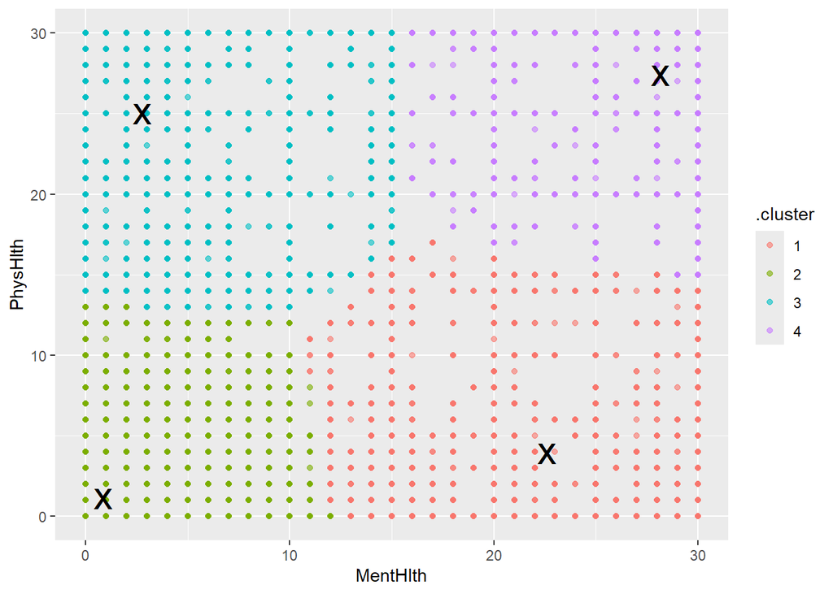

```r
set.seed(123)

augment(kclust, balanced_diabetes_data) %>%
  ggplot() +
  geom_point(aes(x=MentHlth, y=PhysHlth

, color=.cluster), alpha=0.6) +
  geom_point(data = tidy(kclust), aes(x=MentHlth, y=PhysHlth

), size = 8, shape = "x")
```

The mental health vs physical Health data populated the whole graph and so 4 clusters seemed appropriate. Unfortunately could not plot many to find appropriate number of centroids according to elbow plot (explained below.)

I interpret the 2 variables as the higher the better.

## Q4 - Education vs HeartDiseaseorAttack

```r
set.seed(123)

kclust =
  balanced_diabetes_data  %>%
  select(Education
, HeartDiseaseorAttack


) %>%
  kmeans(centers = 3)

tidy(kclust)
```

```
# A tibble: 3 × 5
  Education HeartDiseaseorAttack   size withinss cluster
      <dbl>                <dbl>  <int>    <dbl> <fct>
1      1.97                0.226  20545    4205. 1
2      5.57                0.110 562995  192771. 2
3      3.85                0.156 271272   71188. 3
```

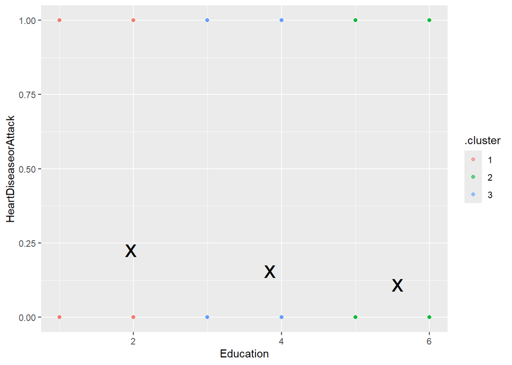

```r
set.seed(123)

augment(kclust, balanced_diabetes_data) %>%
  ggplot() +
  geom_point(aes(x=Education, y=HeartDiseaseorAttack

, color=.cluster), alpha=0.6) +
  geom_point(data = tidy(kclust), aes(x=Education, y=HeartDiseaseorAttack

), size = 8, shape = "x")
```

Based of the data alone it can’t be judged whether education level has an influence on heart disease or attack. This makes sense because if someone is highly educated it could be argued that they would also have enough money to look after their lifestyle. On the other hand they may end up with a high stress job that affects their heart. It wouold be more useful to compare with factors like occupation or diet.

This code thats been commented out was taking too long to run. Its purpose was for me to plot many version with different clusters and to plot the elbow graph. The elbow graph would have told me how many clusters to use by looking at the point where the drop off in variance is starting to be less and less noticeable (the pointy part). This process of finding the appropriate number of centroids is analogous to fitting supervised machine learning models.

```r
# #Multiple Cluster Plots and Elbow plot to determine suitable number of clusters
#
# kclusts <-
#   tibble(k = 1:5) %>%
#   mutate(
#     kclust = map(k, ~kmeans(select(balanced_diabetes_data, MentHlth, PhysHlth), .x)),
#     tidied = map(kclust, tidy),
#     glanced = map(kclust, glance),
#     augmented = map(kclust, augment, balanced_diabetes_data)
#   )
#
# clusters <-
#   kclusts %>%
#   unnest(cols = c(tidied))
#
# assignments <-
#   kclusts %>%
#   unnest(cols = c(augmented))
#
# clusterings <-
#   kclusts %>%
#   unnest(cols = c(glanced))
```

```r
# ggplot(assignments, aes(x = MentHlth, y = PhysHlth)) +
#   geom_point(aes(color = .cluster), alpha = 0.7) +
#   facet_wrap(~ k) +
#   geom_point(data = clusters, size = 4, shape = "x")
```

```r
# ggplot(clusterings, aes(k, tot.withinss)) +
#   geom_line(color="red",alpha=0.5,linewidth=1) +
#   geom_point(color="red",size=4)+
#   theme_grey(base_size = 15)
```

# Part 3

## Q5 - EDA

This section will focus on textual analysis of the drugs reviews and will mainly start from the LDA section onwards. This EDA section was just for me to reach the data and get a big picture sense of what its about.

The research question will be expanded on more after the exploration but this is what it is. Research Question: Can market gaps be spotted by viewing sentiment around the current available drugs for particular conditions (e.g Migraine Prevention’s)?

My approach here is to find the sentiment of the reviews specific to all drugs used for Migraine Prevention. I will then perform topic and conceptual modelling on these reviews using LDA (Latent Dirichlet Allocation) and LSA (Latent Semantic Analysis) respectively. I will consider there to be a gap in the market if there is negative sentiment around current forms of prevention. Topic and conceptual modelling should enable me to understand what the specific details of the complaints are, as well as any nuance in the treatments.

```r
drug_rev_train <- read.csv("C:/Users/David Moraes/Downloads/drug_review_dataset/drugsComTrain_raw.tsv", sep = "\t")

drug_rev_test <- read.csv("C:/Users/David Moraes/Downloads/drug_review_dataset/drugsComTest_raw.tsv", sep = "\t")

head(drug_rev_train)
```

```
       X                 drugName                    condition
1 206461                Valsartan Left Ventricular Dysfunction
2  95260               Guanfacine                         ADHD
3  92703                   Lybrel                Birth Control
4 138000               Ortho Evra                Birth Control
5  35696 Buprenorphine / naloxone            Opiate Dependence
6 155963                   Cialis Benign Prostatic Hyperplasia
                                                                                                                                                                                                                                                                                                            …
1                                                                                                                                                                                                                                                                                                           …
2               "My son is halfway through his fourth week of Intuniv. We became concerned when he began this last week, when he started taking the highest dose he will be on. For two days, he could hardly get out of bed, was very cranky, and slept for nearly 8 hours on a drive home from school vaca…
3 "I used to take another oral contraceptive, which had 21 pill cycle, and was very happy- very light periods, max 5 days, no other side effects. But it contained hormone gestodene, which is not available in US, so I switched to Lybrel, because the ingredients are similar. When my other pills ended,…
4                                                                                                                                                                                                                                                                                                           …
5                                     "Suboxone has completely turned my life around.  I feel healthier, I&#039;m excelling at my job and I always have money in my pocket and my savings account.  I had none of those before Suboxone and spent years abusing oxycontin.  My paycheck was already spent by…
6                                                                                                                                                                                                                                                                                                           …
  rating              date usefulCount
1      9      May 20, 2012          27
2      8    April 27, 2010         192
3      5 December 14, 2009          17
4      8  November 3, 2015          10
5      9 November 27, 2016          37
6      2 November 28, 2015          43
```

```r
head(drug_rev_test)
```

```
       X        drugName                    condition
1 163740     Mirtazapine                   Depression
2 206473      Mesalamine Crohn's Disease, Maintenance
3 159672         Bactrim      Urinary Tract Infection
4  39293        Contrave                  Weight Loss
5  97768 Cyclafem 1 / 35                Birth Control
6 208087         Zyclara                    Keratosis
                                                                                                                                                                                                                                                                                                            …
1                                                                                                                                                                                                                                                                                                           …
2                                                                                                                                                                                                                                                                                                           …
3                                                                                                                                                                                                                                                                                                           …
4 "Contrave combines drugs that were used for alcohol, smoking, and opioid cessation. People lose weight on it because it also helps control over-eating. I have no doubt that most obesity is caused from sugar/carb addiction, which is just as powerful as any drug. I have been taking it for five days,…
5                     "I have been on this birth control for one cycle. After reading some of the reviews on this type and similar birth controls I was a bit apprehensive to start. Im giving this birth control a 9 out of 10 as I have not been on it long enough for a 10. So far I love this birth cont…
6                                                                                                                                                                                                                                                                                                           …
  rating               date usefulCount
1     10  February 28, 2012          22
2      8       May 17, 2009          17
3      9 September 29, 2017           3
4      9      March 5, 2017          35
5      9   October 22, 2015           4
6      4       July 3, 2014          13
```

```r
# Creating a corpus
corpus <- corpus(drug_rev_train$review)

# Viewing the corpus
head(corpus)
```

```
Corpus consisting of 6 documents.
text1 :
""It has no side effect, I take it in combination of Bystolic..."

text2 :
""My son is halfway through his fourth week of Intuniv. We be..."

text3 :
""I used to take another oral contraceptive, which had 21 pil..."

text4 :
""This is my first time using any form of birth control. I&#0..."

text5 :
""Suboxone has completely turned my life around.  I feel heal..."

text6 :
""2nd day on 5mg started to work with rock hard erections how..."
```

```r
summary(corpus)
```

```
Corpus consisting of 161297 documents, showing 100 documents:

    Text Types Tokens Sentences
   text1    19     20         1
   text2   105    164        11
   text3    99    170         9
   text4    66    103         5
   text5    95    155        11
   text6    68     92         5
   text7    32     40         2
   text8    98    170        13
   text9    30     47         1
  text10   109    173        10
  text11   103    171         6
  text12    65     94         6
  text13    63     84         4
  text14    86    142         7
  text15   101    186         7
  text16   113    164        10
  text17    97    138         5
  text18   102    168         9
  text19   112    177         9
  text20    76    117         3
  text21    74    111         6
  text22    97    177        12
  text23    69     94         7
  text24    90    146         5
  text25    40     47         4
  text26    64     85         4
  text27   122    168        10
  text28   115    161         9
  text29    75    106         5
  text30   106    166        14
  text31    11     13         3
  text32    47     60         5
  text33    50     72         6
  text34    25     29         3
  text35    31     41         3
  text36    16     17         1
  text37    64    102         6
```

[output cut: 48 more lines]

```
  text86    18     19         2
  text87    68    103         7
  text88   105    193         6
  text89   112    156        11
  text90    55     64         5
  text91    46     58         4
  text92   109    163         7
  text93    99    171        10
  text94    96    147         8
  text95   100    157         3
  text96    88    135         4
  text97    71     97         9
  text98   108    174        12
  text99    88    165        11
 text100    97    158         9
```

```r
# Tokenizing the corpus
tokens <- tokens(corpus)

# Viewing the tokens
head(tokens)
```

```
Tokens consisting of 6 documents.
text1 :
 [1] "\""          "It"          "has"         "no"          "side"
 [6] "effect"      ","           "I"           "take"        "it"
[11] "in"          "combination"
[ ... and 8 more ]

text2 :
 [1] "\""      "My"      "son"     "is"      "halfway" "through" "his"
 [8] "fourth"  "week"    "of"      "Intuniv" "."
[ ... and 152 more ]

text3 :
 [1] "\""            "I"             "used"          "to"
 [5] "take"          "another"       "oral"          "contraceptive"
 [9] ","             "which"         "had"           "21"
[ ... and 158 more ]

text4 :
 [1] "\""      "This"    "is"      "my"      "first"   "time"    "using"
 [8] "any"     "form"    "of"      "birth"   "control"
[ ... and 91 more ]

text5 :
 [1] "\""         "Suboxone"   "has"        "completely" "turned"
 [6] "my"         "life"       "around"     "."          "I"
[11] "feel"       "healthier"
[ ... and 143 more ]

text6 :
 [1] "\""        "2nd"       "day"       "on"        "5mg"       "started"
 [7] "to"        "work"      "with"      "rock"      "hard"      "erections"
[ ... and 80 more ]
```

```r
# Creating a DFM
dfm <- dfm(tokens)

# Viewing the DFM
dfm
```

```
Document-feature matrix of: 161,297 documents, 60,641 features (99.89% sparse) and 0 docvars.
       features
docs    " it has no side effect  , i take in
  text1 2  2   1  1    1      1  1 1    1  1
  text2 2  1   0  0    0      0  6 1    0  1
  text3 2  2   0  1    3      0 11 5    1  1
  text4 2  3   0  0    0      0  2 5    0  1
  text5 2  3   1  0    0      0  2 9    0  2
  text6 2  0   0  0    2      0  1 1    0  0
[ reached max_ndoc ... 161,291 more documents, reached max_nfeat ... 60,631 more features ]
```

This will be redone for LDA and sentiment analysis.

```r
# Lowercasing and removing punctuation
tokens_clean <- tokens(corpus,
                       what = "word",
                       remove_punct = TRUE) %>%
                tokens_tolower()

# Removing stopwords
tokens_clean <- tokens_select(tokens_clean,
                              pattern = stopwords("en"),
                              selection = "remove")

# Stemming
tokens_stemmed <- tokens_wordstem(tokens_clean, language = "english")

# Creating a DFM from cleaned and stemmed tokens
dfm_clean <- dfm(tokens_stemmed)

# Viewing the cleaned DFM
dfm_clean
```

```
Document-feature matrix of: 161,297 documents, 46,708 features (99.92% sparse) and 0 docvars.
       features
docs    side effect take combin bystol 5 mg fish oil son
  text1    1      1    1      1      1 1  1    1   1   0
  text2    0      1    1      0      0 0  0    0   0   1
  text3    3      2    2      0      0 1  0    0   0   0
  text4    0      0    0      0      0 0  0    0   0   0
  text5    0      0    0      0      0 0  0    0   0   0
  text6    2      2    0      0      0 0  0    0   0   0
[ reached max_ndoc ... 161,291 more documents, reached max_nfeat ... 46,698 more features ]
```

```r
# Top features
topfeatures(dfm_clean, n = 25)
```

```
  #039   take      t    day  month   year effect   work   week    get  start
262415  98396  98154  97611  69946  66076  63410  62393  58548  58284  57394
   now   pain      m   side   feel   time     ve      s  first   like   pill
 55271  55019  54598  53087  52810  51051  47796  46960  45073  43137  41818
   use period   just
 40778  40531  40074
```

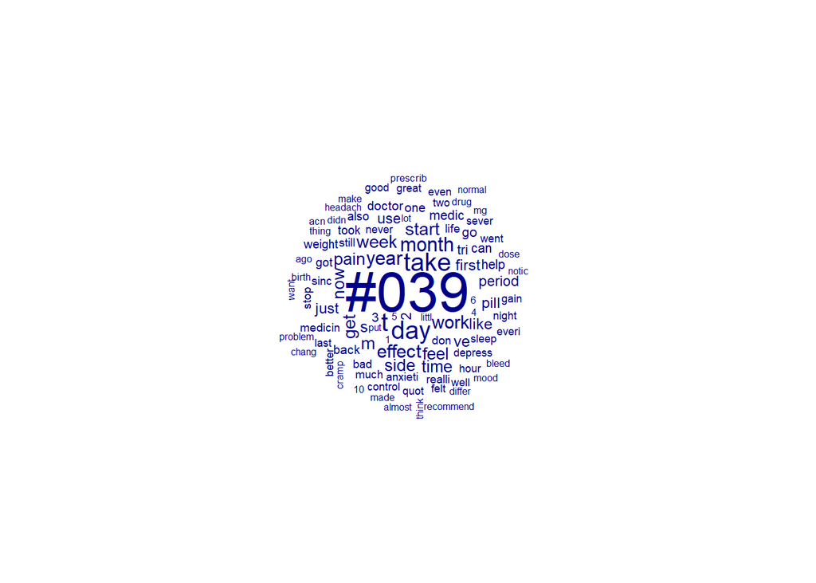

```r
# Wordcloud
library(quanteda.textplots)
textplot_wordcloud(dfm_clean, min_count = 1, max_words = 100)
```

## Q5 - Sentiment Analysis

Here onwards I begin sentiment analysis using the dictionary AFINN to gather my list of positive and negative words. These words also have a respective positive and negative score which I could use to compare reviews to see which are relatively more negative or positive than others. Doing so could allow me to find my competitors in the drug market and tell me who I don’t need to worry about.

```r
AFINN <- get_sentiments("afinn")

AFINN
```

```
# A tibble: 2,477 × 2
   word       value
   <chr>      <dbl>
 1 abandon       -2
 2 abandoned     -2
 3 abandons      -2
 4 abducted      -2
 5 abduction     -2
 6 abductions    -2
 7 abhor         -3
 8 abhorred      -3
 9 abhorrent     -3
10 abhors        -3
# ℹ 2,467 more rows
```

```r
# Concatenate the text from 'drugName', 'condition', and 'review' columns
text_data <- paste(drug_rev_train$drugName, drug_rev_train$condition, drug_rev_train$review, sep = " ")

# Create a corpus
corpus_sentiment <- corpus(text_data)
```

```r
# Extract the words and their corresponding sentiment scores
afinn_words <- AFINN$word
afinn_scores <- AFINN$value

# Split the words based on sentiment scores
positive_words <- afinn_words[afinn_scores > 0]
negative_words <- afinn_words[afinn_scores < 0]

# Print the lists
print("Positive words:")
```

```
[1] "Positive words:"
```

```r
head(positive_words)
```

```
[1] "abilities" "ability"   "aboard"    "absolve"   "absolved"  "absolves"
```

```r
print("Negative words:")
```

```
[1] "Negative words:"
```

```r
head(negative_words)
```

```
[1] "abandon"    "abandoned"  "abandons"   "abducted"   "abduction"
[6] "abductions"
```

## Q5 - Overall sentiment across training data

```r
# Tokenization and cleaning
tokens <- tokens(corpus_sentiment, remove_punct = TRUE) %>%
          tokens_tolower() %>%
          tokens_select(pattern = stopwords("en"), selection = "remove") %>%
          tokens_wordstem(language = "english")

# Creating a DFM
dfm_clean <- dfm(tokens)

# Load a sentiment dictionary
data_dictionary_LSD2015 <- dictionary(list(
  positive = positive_words,
  negative = negative_words
))

# Apply the dictionary using dfm_lookup
dfm_sentiment <- dfm_lookup(dfm_clean, dictionary = data_dictionary_LSD2015)

# Viewing the sentiment analysis result
print(dfm_sentiment)
```

```
Document-feature matrix of: 161,297 documents, 2 features (19.74% sparse) and 0 docvars.
       features
docs    positive negative
  text1        0        0
  text2        3        2
  text3        1        0
  text4        1        2
  text5        4        2
  text6        3        2
[ reached max_ndoc ... 161,291 more documents ]
```

## Q5 - Research Question: Can market gaps be spotted by viewing sentiment around the current available drugs for particular conditions (e.g Migraine Preventions)?

```r
# Create a dataframe
drug_sentiment <- data.frame(drugName = drug_rev_train$drugName,
                               condition = drug_rev_train$condition,
                               review = drug_rev_train$review)

# Optionally, you can convert the 'review' column to character type
drug_sentiment$review <- as.character(drug_sentiment$review)

library(tibble)

# Convert to tibble
drug_sentiment <- as_tibble(drug_sentiment)

# View the dataframe
head(drug_sentiment)
```

```
# A tibble: 6 × 3
  drugName                 condition                    review
  <chr>                    <chr>                        <chr>
1 Valsartan                Left Ventricular Dysfunction "\"It has no side effec…
2 Guanfacine               ADHD                         "\"My son is halfway th…
3 Lybrel                   Birth Control                "\"I used to take anoth…
4 Ortho Evra               Birth Control                "\"This is my first tim…
5 Buprenorphine / naloxone Opiate Dependence            "\"Suboxone has complet…
6 Cialis                   Benign Prostatic Hyperplasia "\"2nd day on 5mg start…
```

```r
# Filter the dataframe for reviews with the condition "migraine prevention"
subset_reviews <- subset(drug_sentiment, condition == "Migraine Prevention")

head(subset_reviews)
```

```
# A tibble: 6 × 3
  drugName           condition           review
  <chr>              <chr>               <chr>
1 Topiramate         Migraine Prevention "\"I have been on this medication almo…
2 Amitriptyline      Migraine Prevention "\"Wanted to share this with everyone.…
3 Topamax            Migraine Prevention "\"I&#039;ve taking topamax for three …
4 Topiramate         Migraine Prevention "\"I have been taking 75mg topamax one…
5 Topamax            Migraine Prevention "\"I was in a car accident with a head…
6 OnabotulinumtoxinA Migraine Prevention "\"Tried everything before Botox. This…
```

```r
# Tokenization and cleaning
tokens <- tokens(subset_reviews$review, remove_punct = TRUE) %>%
          tokens_tolower() %>%
          tokens_select(pattern = stopwords("en"), selection = "remove") %>%
          tokens_wordstem(language = "english")

# Creating a DFM
dfm_clean <- dfm(tokens)

# Load a sentiment dictionary
data_dictionary_LSD2015 <- dictionary(list(
  positive = positive_words,
  negative = negative_words
))

# Apply the dictionary using dfm_lookup
dfm_sentiment_migraine <- dfm_lookup(dfm_clean, dictionary = data_dictionary_LSD2015)

# Viewing the sentiment analysis result
print(dfm_sentiment_migraine)
```

```
Document-feature matrix of: 1,413 documents, 2 features (20.21% sparse) and 0 docvars.
       features
docs    positive negative
  text1        6        5
  text2        4        4
  text3        2        3
  text4        4        2
  text5        2        2
  text6        0        0
[ reached max_ndoc ... 1,407 more documents ]
```

```r
library(ggplot2)
```

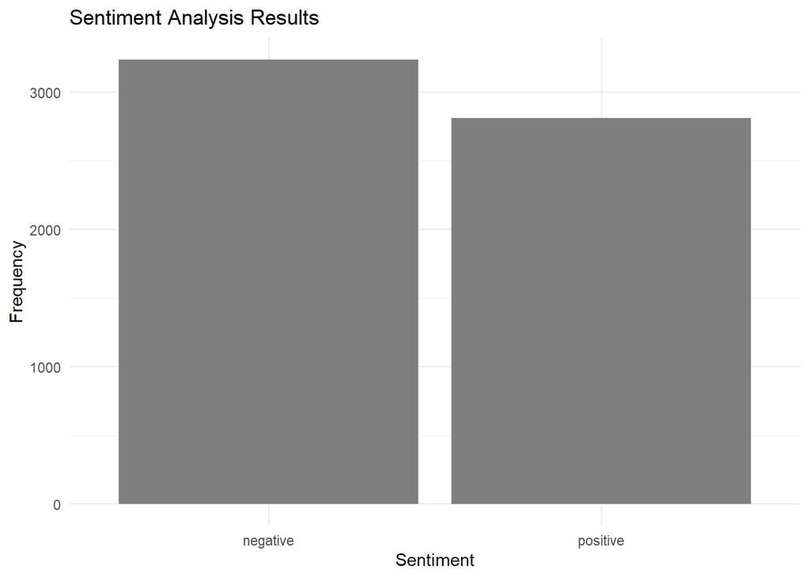

```r
# Convert dfm_sentiment_migraine to a data frame for plotting
dfm_df <- convert(dfm_sentiment_migraine, to = "data.frame")

# Reshape the data for plotting
dfm_df_long <- tidyr::pivot_longer(dfm_df, cols = c("positive", "negative"), names_to = "Sentiment", values_to = "Frequency")

# Plotting the sentiment analysis results
ggplot(dfm_df_long, aes(x = Sentiment, y = Frequency, fill = Sentiment)) +
  geom_bar(stat = "identity") +
  labs(x = "Sentiment", y = "Frequency", fill = "Sentiment", title = "Sentiment Analysis Results") +
  scale_fill_manual(values = c("Positive" = "green", "Negative" = "red")) +
  theme_minimal()
```

It could be argued that there is still a gap in the market for migraine prevention treatments. In general sentiment from is about 50/50 with negative experiences taking precedence. This will be corroborated later when we see how LSA also reveals a negative sentiment pervasive throughout the drug reviews associated with migraine prevention.

```r
corpus_migraine <- corpus(subset_reviews$review)

# Sample a subset of the corpus for migraine prevention reviews
sample_size <- 100  # Adjust as needed
corpus_subset <- corpus_migraine[sample(seq_len(ndoc(corpus_migraine)), size = sample_size)]

head(corpus_subset)
```

```
Corpus consisting of 6 documents.
text505 :
""I have been having migraines for 3 years. I took a beta blo..."

text1103 :
""Topamax worked great to relieve my daily headaches and migr..."

text941 :
""Trouble concentrating and some memory problems""

text137 :
""I have been on Depakote ER 1000 mg/day for over 7 years now..."

text1355 :
""Have had a mixture of Trigeminal Neuralgia and Cluster Migr..."

text653 :
""I took Topamax a few years ago and regret it. It has change..."
```

```r
# Tokenization and cleaning
tokens <- tokens(corpus_subset, remove_punct = TRUE) %>%
          tokens_tolower() %>%
          tokens_select(pattern = stopwords("en"), selection = "remove") %>%
          tokens_wordstem(language = "english")

# Creating bigrams (n-grams with n = 2)
tokens_bigrams <- tokens_ngrams(tokens, n = 2)

# Viewing bigrams
head(tokens_bigrams)
```

```
Tokens consisting of 6 documents.
text505 :
 [1] "migrain_3"    "3_year"       "year_took"    "took_beta"    "beta_blocker"
 [6] "blocker_didn" "didn_#039"    "#039_t"       "t_work"       "work_got"
[11] "got_put"      "put_depakot"
[ ... and 24 more ]

text1103 :
 [1] "topamax_work"    "work_great"      "great_reliev"    "reliev_daili"
 [5] "daili_headach"   "headach_migrain" "migrain_take"    "take_twice"
 [9] "twice_daili"     "daili_didn"      "didn_#039"       "#039_t"
[ ... and 58 more ]

text941 :
[1] "troubl_concentr" "concentr_memori" "memori_problem"

text137 :
 [1] "depakot_er"    "er_1000"       "1000_mg"       "mg_day"
 [5] "day_7"         "7_year"        "year_now"      "now_4"
 [9] "4_migrain"     "migrain_month" "month_pretti"  "pretti_much"
[ ... and 33 more ]

text1355 :
 [1] "mixtur_trigemin"     "trigemin_neuralgia"  "neuralgia_cluster"
 [4] "cluster_migrain"     "migrain_chronic"     "chronic_paroxysm"
 [7] "paroxysm_hemicrania" "hemicrania_14"       "14_year"
[10] "year_tri"            "tri_everi"           "everi_singl"
[ ... and 61 more ]

text653 :
 [1] "took_topamax" "topamax_year" "year_ago"     "ago_regret"   "regret_chang"
 [6] "chang_life"   "life_wors"    "wors_even"    "even_stop"    "stop_med"
[11] "med_sever"    "sever_year"
[ ... and 66 more ]
```

## Q5 - LDA

My hope with LDA would be to find major themes in the reviews. This could alert me to tolerable or intolerable side effects, which drugs are the main ones being used (from my sample of data) and perhaps what general life experience is like for migraine sufferers. Understanding all this would give a company the information it needs to craft and market a medicine that appeals to migraine sufferers.

```r
library(topicmodels)
library(tm)
# Define your custom list of stop words
custom_stopwords <- c("#039", "year", "month", "day", "s", "effect", "take", "t", "m",
  "start", "like", "work", "also", "just", "much", "ve", "now", "tri",
  "feel", "time", "get", "side", "pain", "help", "go", "3", "pill",
  "use", "week", "2", "doctor", "medic", "will", "can", "quot", "sinc",
  "went", "first", "one", "night", "ve", "now", "tri", "feel", "time", "month", "take", "get", "year",
  "took", "take", "work", "help", "go", "3", "pill", "day", "use",
  "week", "2", "doctor", "medic", "will", "can", "got", "month",
  "effect", "went", "first", "one", "year" )  # Add your stop words here

# Combine custom stop words with default stop words
all_stopwords <- c(stopwords("en"), custom_stopwords)


# Tokenization and cleaning
tokens_clean <- tokens(corpus_subset, remove_punct = TRUE) %>%
                tokens_tolower() %>%
                tokens_select(pattern = all_stopwords, selection = "remove") %>%
                tokens_wordstem(language = "english")

# Creating a DFM
dfm_clean <- dfm(tokens_clean)

# Removing sparse terms
dfm_clean <- dfm_trim(dfm_clean, min_termfreq = 1, min_docfreq = 1)

# Converting DFM to a Document-Term Matrix
dtm <- as.DocumentTermMatrix(dfm_clean, weighting = weightTf)

# Fitting the LDA model with 2 topics
lda_model <- LDA(dtm, k = 5, control = list(seed = 1234))

# Getting the terms associated with topics
top_terms <- terms(lda_model, 10)  # Get top 5 terms for each topic

# Getting the topic distribution for each document
doc_topics <- topics(lda_model)  # Get the most likely topic for each document

# Getting the topic probabilities for each document
topic_probabilities <- posterior(lda_model)$topics

# Viewing the results
head(top_terms)
```

```
     Topic 1   Topic 2   Topic 3   Topic 4   Topic 5
[1,] "migrain" "migrain" "migrain" "migrain" "migrain"
[2,] "year"    "topamax" "headach" "headach" "effect"
[3,] "botox"   "back"    "start"   "1"       "drug"
[4,] "ago"     "take"    "medicin" "inject"  "year"
[5,] "tingl"   "month"   "mg"      "everi"   "medic"
[6,] "day"     "effect"  "take"    "medic"   "work"
```

```r
head(doc_topics)
```

```
 text505 text1103  text941  text137 text1355  text653
       5        1        4        5        4        1
```

```r
head(topic_probabilities)
```

```
                    1            2            3            4            5
text505  0.0008556035 0.0008556035 0.0008556035 0.0008556035 0.9965775861
text1103 0.8574527520 0.1413286466 0.0004062005 0.0004062005 0.0004062005
text941  0.0056366693 0.0056366693 0.0056366693 0.9774533230 0.0056366693
text137  0.0007005841 0.0007005841 0.0007005841 0.0007005841 0.9971976635
text1355 0.0003675858 0.0003675858 0.0003675858 0.9985296568 0.0003675858
text653  0.9985296568 0.0003675858 0.0003675858 0.0003675858 0.0003675858
```

LDA is an unsupervised learning method to model the topics in documents you feed it. A limitation is that you have to specify how many topics you want it to identify. It wont tell you the total number of topics in a document or what they all are. That could be done with further analysis using LSA. LDA is similar to PCA in the sense that it also reduces the dimensionality of text data.

To summarise these themes into 2 categories its migraines (1) and their prevention’s (2). Just looking at the words, some things that could be inferred are duration of efficacy or how long migraines last. Possible side effects of the preventative drugs or simply symptoms of migraines. Finally, which preventative treatments standout from whats currently available on the market.

## Q5 - LSA

With LSA we can model the concepts in the reviews after removing typical stop words and speific ones that seem to appear in drug reviews.

```r
library(quanteda)
library(text2vec)
```

```r
# Preprocess and tokenize text using text2vec
tokens <- tokens(corpus_subset, remove_punct = TRUE) %>%
          tokens_tolower() %>%
          tokens_select(pattern = stopwords("en"), selection = "remove") %>%
          tokens_wordstem(language = "english")

# Convert tokens to a list of character vectors
tokens_list <- as.list(tokens)

# Create an iterator over tokens
it <- itoken(tokens_list, progressbar = FALSE)

# Create vocabulary
vocab <- create_vocabulary(it)

# Create a document-term matrix
vectorizer <- vocab_vectorizer(vocab)
dtm <- create_dtm(it, vectorizer)

# Perform LSA
lsa_model <- LSA$new(n_topics = 5)
doc_topic_matrix <- lsa_model$fit_transform(dtm)
```

[output not shown]

```r
# Print the topic-term matrix and document-topic matrix
View(lsa_model$components)  # Topic-term matrix
```

```r
View(doc_topic_matrix)  # Document-topic matrix
```

Interpretation of LSA results:

Finally we see the emotional states of the patients through words like anxious, anger, calm, confus, depress, dream, feel, happy, mood, nervous, panic, sad, tire, worri. This actually confirms what we saw earlier, there was negative sentiment among patients who took drugs for migraine prevention. Perhaps I could have continued this by seeing if there was any correlation between dosage amounts and side effects.

Collectively the understanding of sentiment, nuance of situation and understanding of customer could enable a pharmaceutical company to make a migraine prevention drug that can beat the current ones in the market. The same textual analysis could be applied to a larger data set than the training data set so gather more insight and analysis. What I did was intended to demonstrate the possible insights from quick textual analysis (within the time constraint)